# Lab 12: Network Analysis using Cytoscape and RCy3

## Basic Data Visualization Tutorial

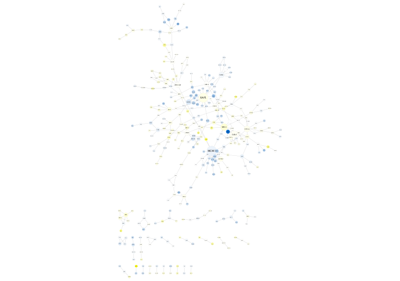

Example of a default network from cytoscape. The data used are from yeast in which GAL1, GAL4, and GAL80 genes were perturbed.

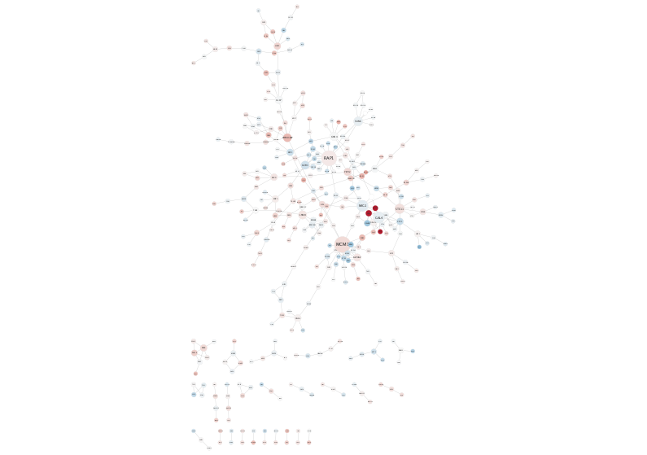

Here we set the node fill color of the gal80Rexp to a gradient ranging from blue to red.

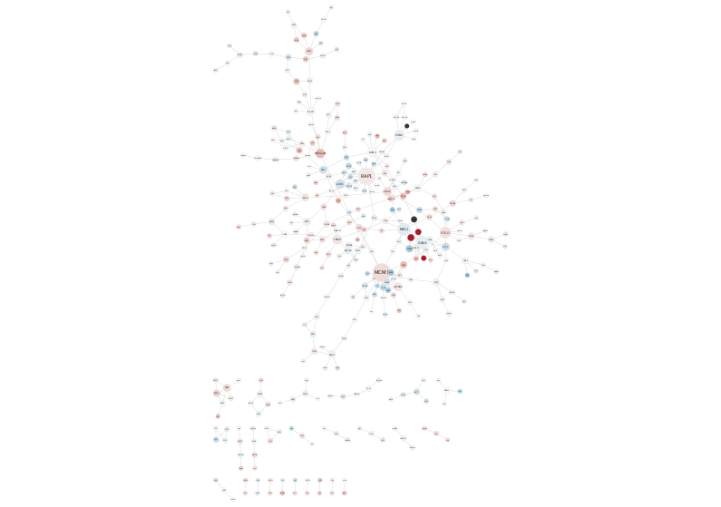

Here we set the default node color to a dark-grey color (originally blue).

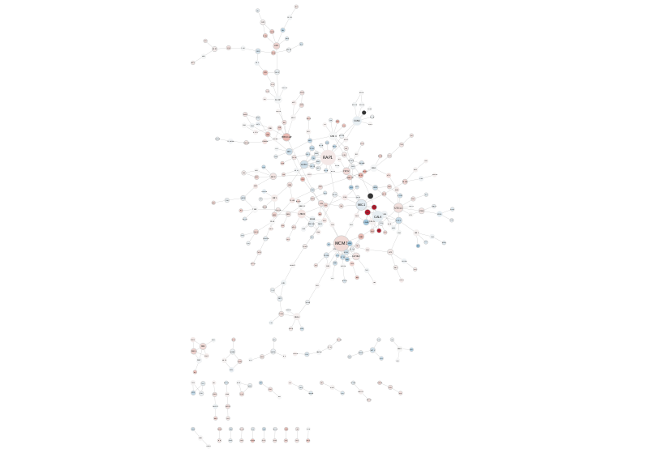

Here we set the node border width to 10 for anything with significance value less than 0.05

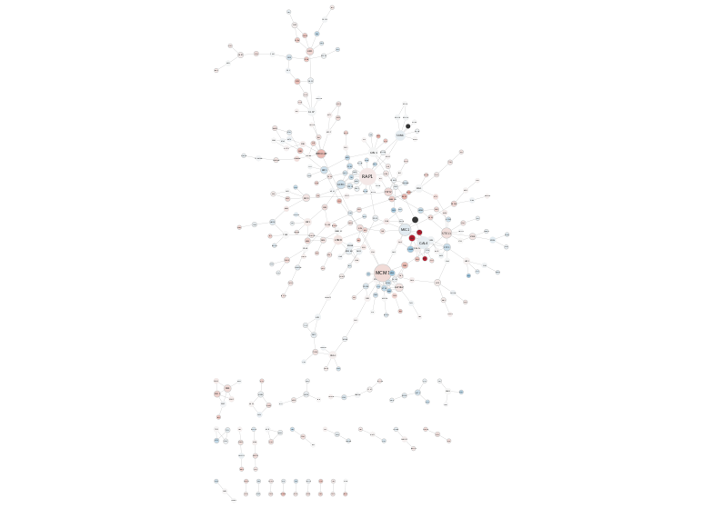

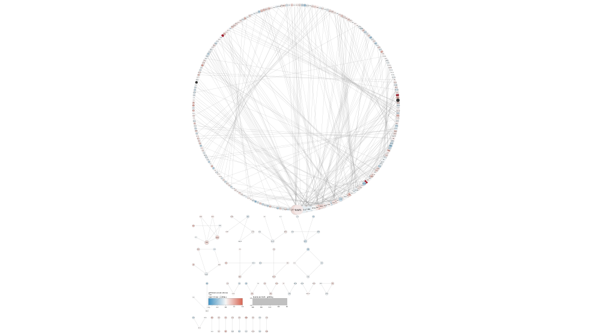

Here we changed the layout to a degree sorted circle layout.

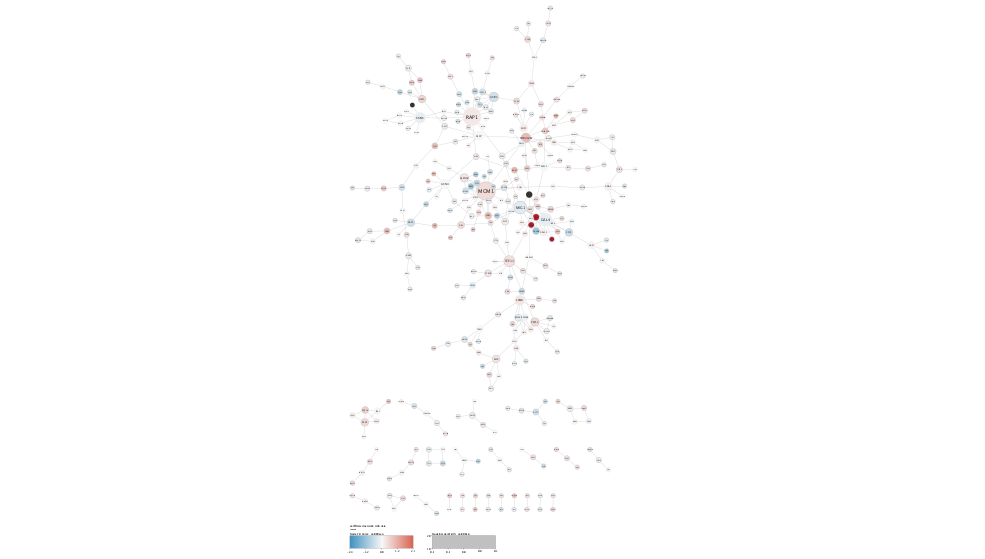

Here we converted the layout to a prefuse force-directed layout.

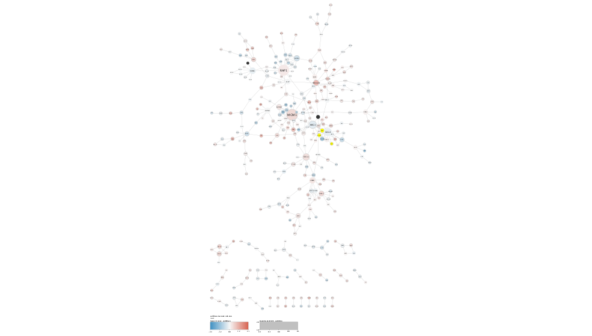

Here we selected nodes that were 2 or higher (highlighted yellow).

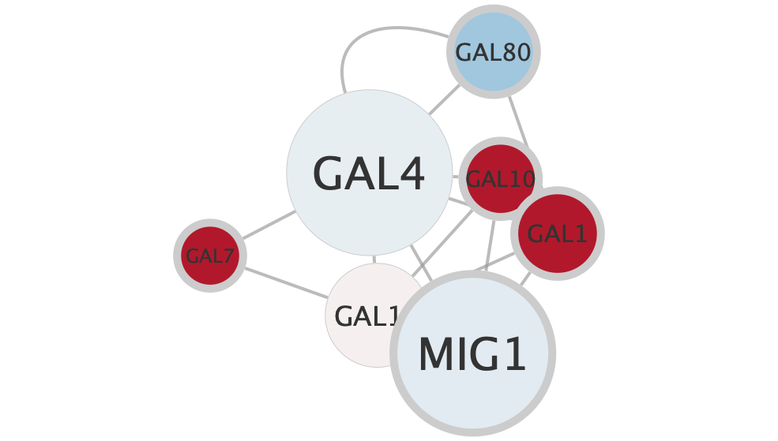

Here we expanded the nodes to include nearest neighbors to the previous network and then created a new network.

## Differentially Expressed Genes Tutorial

### Example 1

#### Upregulated Genes

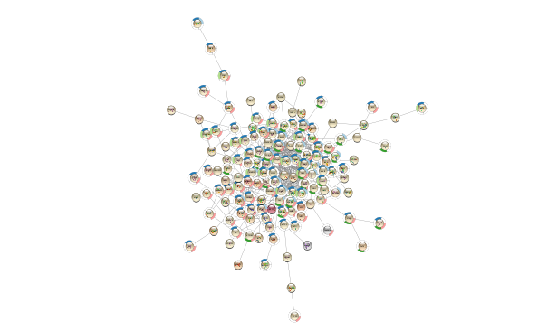

Here is a network showing upregulated genes in ovarian cancer. The string enrichment analysis is represented by split donuts.

#### Downregulated Genes

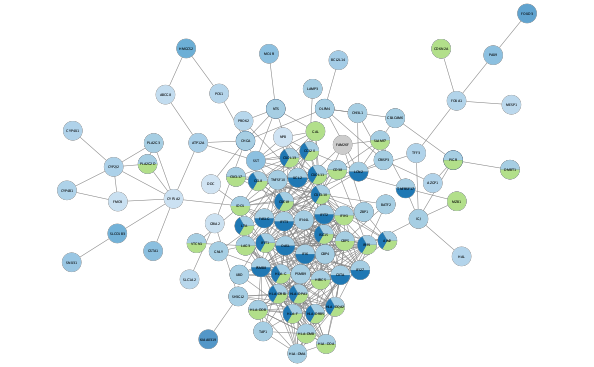

Here is a network showing downregulated genes in ovarian cancer. The string enrichment analysis is represented by pie charts.

### Example 2

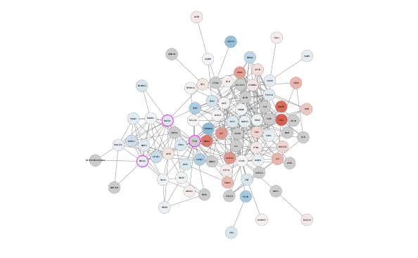

Here is a network highlighting three genes that were identified as drivers of ovarian cancer: BRCA1, BRCA2, and TP53.

## RCy3 Vignette

Load Rcy3 package and ensure connection with Cytoscape

```r
library(RCy3)
cytoscapePing()
```

```
## [1] "You are connected to Cytoscape!"
```

### My first network

*Create a Cytoscape network from some basic R objects.*

```r
# nodes <- data.frame(id=c("node 0","node 1","node 2","node 3"),
#           group=c("A","A","B","B"), # categorical strings
#           score=as.integer(c(20,10,15,5)), # integers
#           stringsAsFactors=FALSE)
# edges <- data.frame(source=c("node 0","node 0","node 0","node 2"),
#           target=c("node 1","node 2","node 3","node 3"),
#          interaction=c("inhibits","interacts","activates","interacts"),  # optional
#           weight=c(5.1,3.0,5.2,9.9), # numeric
#           stringsAsFactors=FALSE)

# createNetworkFromDataFrames(nodes, edges, title="my first network", collection="DataFrame Example")
```

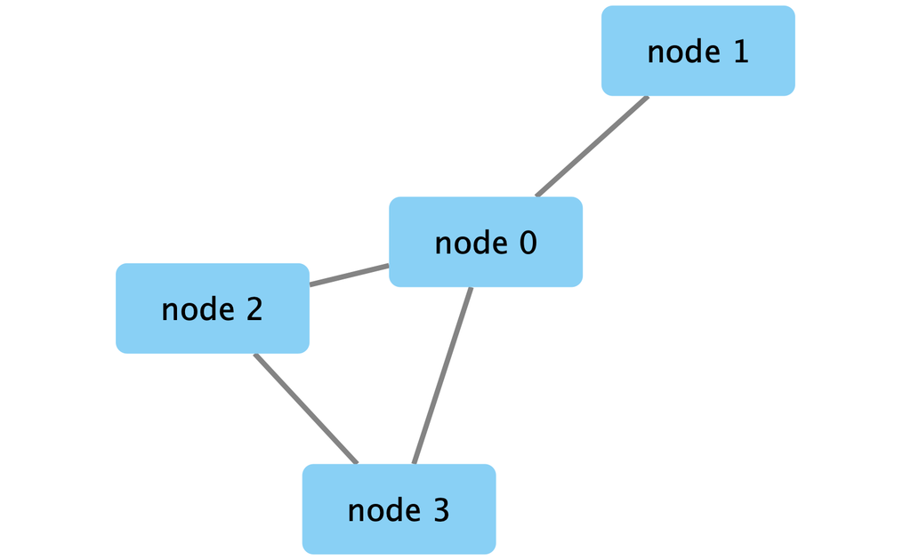

Here is the basic network for the My First Network example.

*Switch to the marquee style.*

```r
# setVisualStyle('Marquee')
```

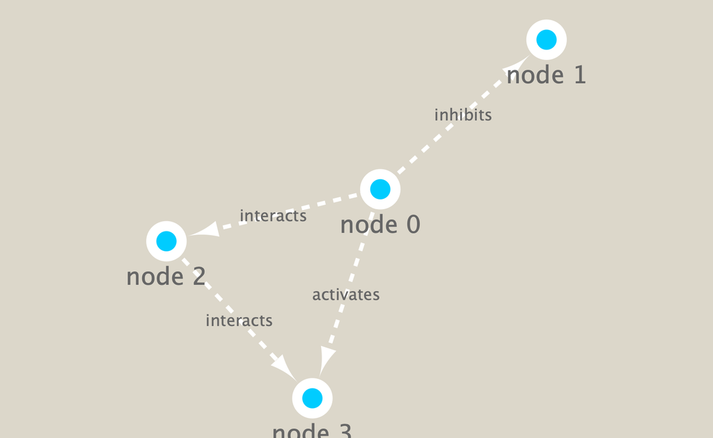

Here is the marquee-styled network for the My First Network example.

*Create custom style with node attribute fill mappings and some defaults.*

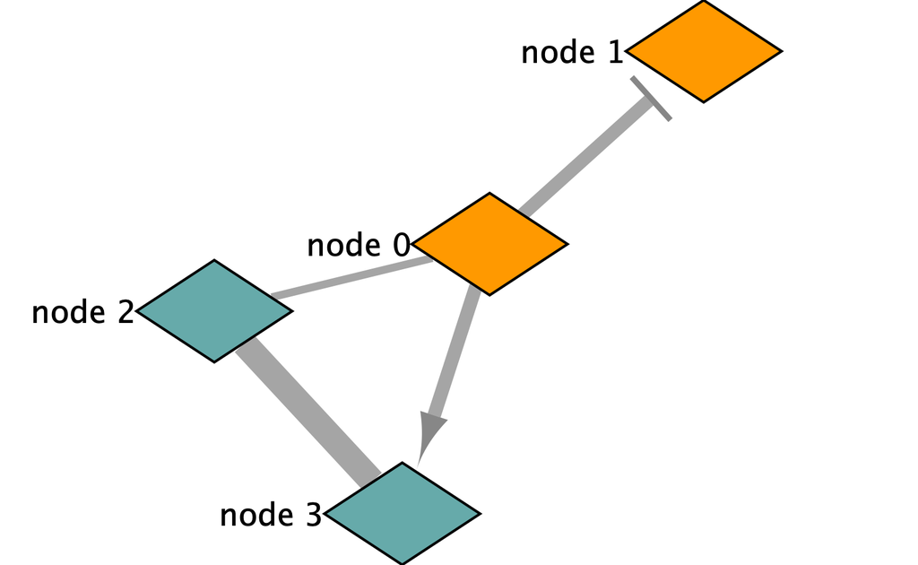

Here is the custom-styled network for the My First Network example.

```r
# style.name = "myStyle"
# defaults <- list(NODE_SHAPE="diamond",
#                 NODE_SIZE=30,
#                 EDGE_TRANSPARENCY=120,
#                 NODE_LABEL_POSITION="W,E,c,0.00,0.00")
# nodeLabels <- mapVisualProperty('node label','id','p')
# nodeFills <- mapVisualProperty('node fill color','group','d',c("A","B"), c("#FF9900","#66AAAA"))
# arrowShapes <- mapVisualProperty('Edge Target Arrow Shape','interaction','d',c("activates","inhibits","interacts"),c("Arrow","T","None"))
# edgeWidth <- mapVisualProperty('edge width','weight','p')

# createVisualStyle(style.name, defaults, list(nodeLabels,nodeFills,arrowShapes,edgeWidth))
# setVisualStyle(style.name)
```

```r
# lockNodeDimensions(FALSE, style.name)
```

### Bioconductor graph example

*We can also start from a Bioconductor graphNEL object. Here we create a basic network.*

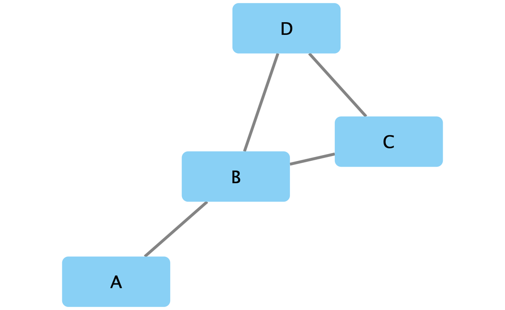

Here is the basic network for the Bioconductor Graph example.

```r
# g = new ('graphNEL', edgemode='directed')
# g = graph::addNode ('A', g)
# g = graph::addNode ('D', g)
# g = graph::addNode ('C', g, edges = list('D'))
# g = graph::addNode ('B', g, edges = list(c('A','D','C')))
# createNetworkFromGraph (g, title='simple network', collection='GraphNEL Example')
```

Next, we add attributes, in this case moleculeType and log2fc, to the node table

```r
# df <- data.frame (moleculeType=c('kinase','TF','cytokine','cytokine'),
#                 log2fc=c(1.8,3.0,-1.2,-2.5),
#                 row.names = c('A','B','C','D'), # row.names = node names
#                 stringsAsFactors = FALSE)       # important when loading strings!
# loadTableData (df)
```

*Next, we change the default styles in Cytoscape.*

```r
# setNodeShapeDefault ('OCTAGON')
# setNodeColorDefault ('#AAFF88')
# setNodeSizeDefault  (60)
# setNodeFontSizeDefault (30)
```

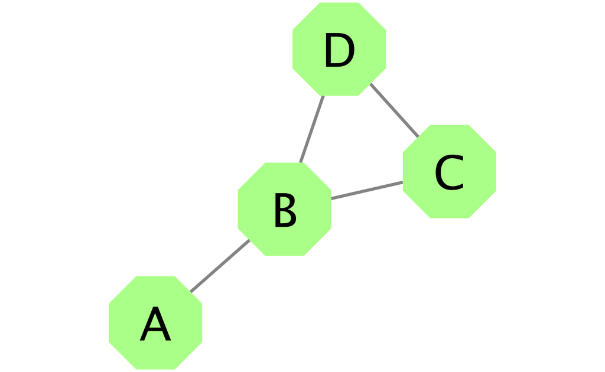

Here is the network after changing the default styles.

*Next, we can map moleculeType to node shapes.*

```r
# getNodeShapes ()   # diamond, ellipse, trapezoid, triangle, etc.
# column <- 'moleculeType'
# values <- c ('kinase',  'TF','cytokine')
# shapes <- c ('DIAMOND', 'TRIANGLE', 'RECTANGLE')
# setNodeShapeMapping (column, values, shapes)
```

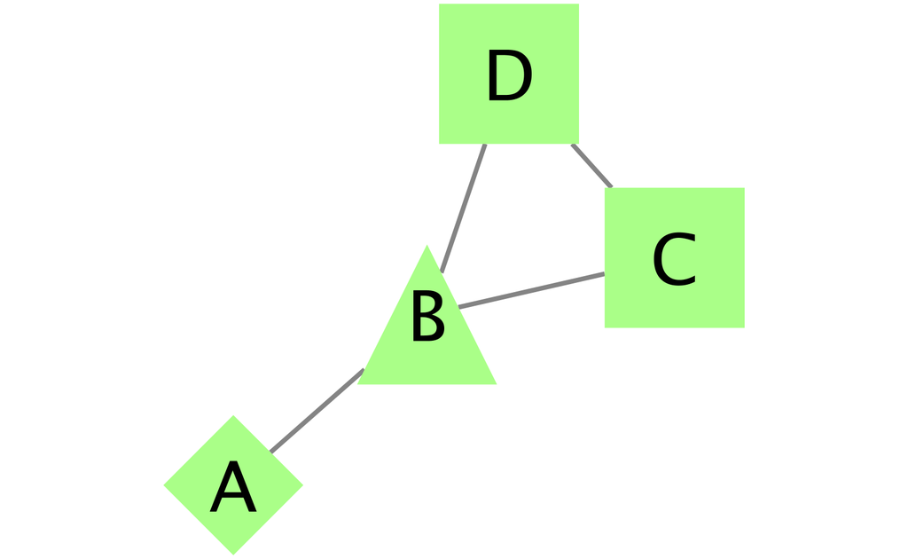

Here is the network after mapping molecule types to node shape.

*Next, we map expression values (log2fc) to node color as a continuous gradient.*

```r
# column <- 'log2fc'
# control.points <- c (-3.0, 0.0, 3.0)
# colors <-  c ('#5588DD', '#FFFFFF', '#DD8855')
# setNodeColorMapping (column, control.points, colors)
```

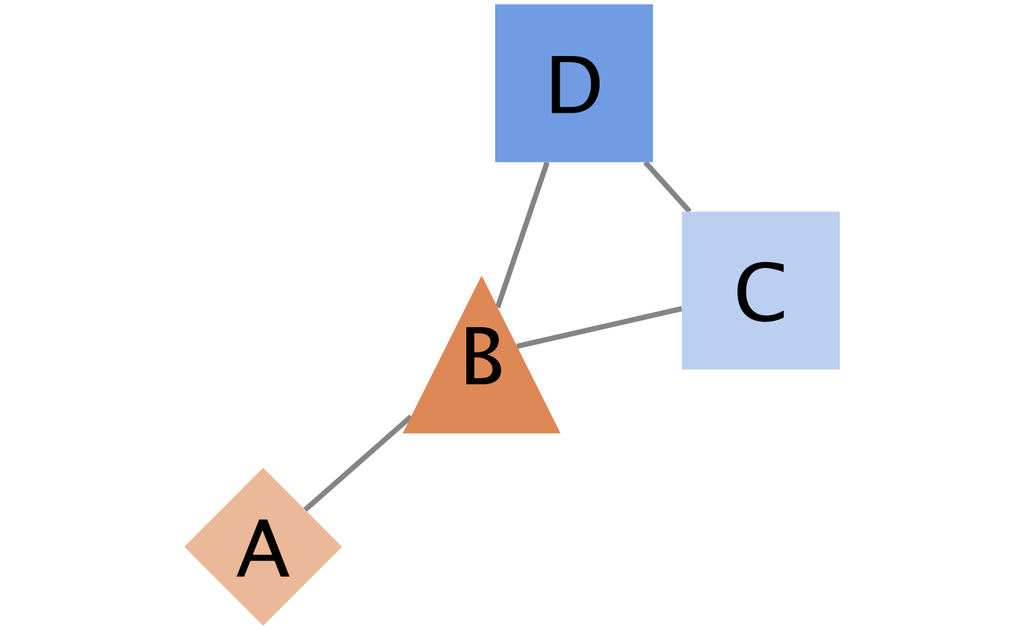

Here is the network after mapping expression values to node color.

*Next, we map two additional colors to set extreme colors for values less than or greater than the control points.*

```r
# control.points <- c (-2.0, 0.0, 2.0)
# colors <-  c ('#2255CC', '#5588DD', '#FFFFFF', '#DD8855','#CC5522')
# setNodeColorMapping (column, control.points, colors)
```

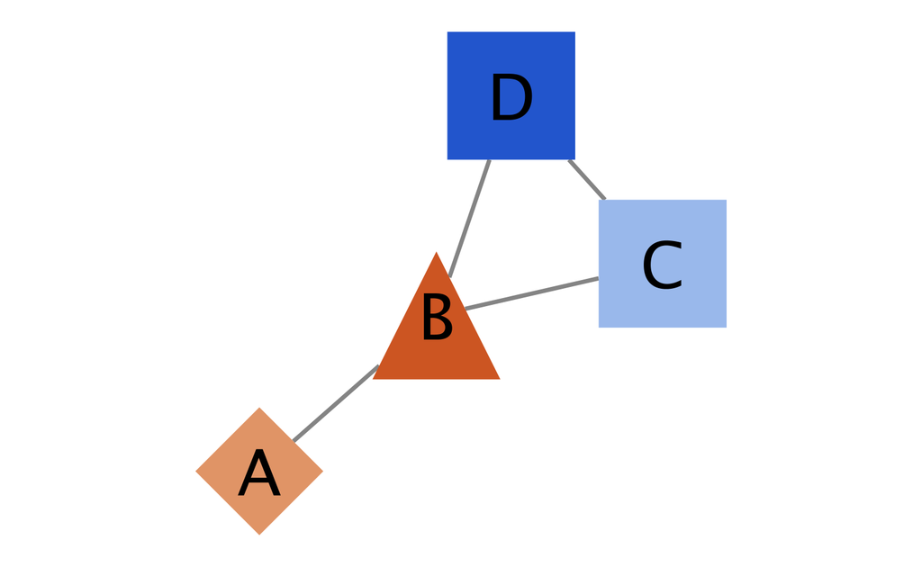

*Next, we add a node size rule that changes the size of node relative to the log2fc value.*

```r
# control.points = c (-3.0, 2.0, 3.0)
# sizes     = c (20, 80, 90)
# setNodeSizeMapping (column, control.points, sizes)
```

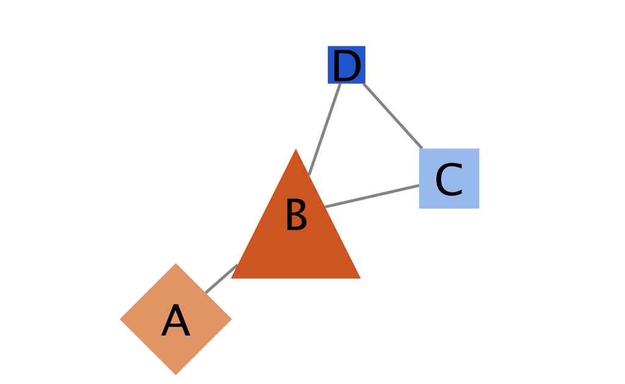

Here is the network after adding a node size rule that changes the size of the node relative to the log2fc value.

*To select a specific node, you can use the selectNodes() function.*

```r
# selectNodes ('C','name')
# getSelectedNodes ()
```

*To select first neighbors to your selected nodes, use the selectFirstNeighbors() function.*

```r
# selectFirstNeighbors ()
```

*To pull the names of selected names into R as a list, use the function getSelectedNodes().*

```r
# node.names <- getSelectedNodes ()
```

*To deselect nodes, use the function clearSelection().*

```r
# clearSelection()
# ?clearSelection
```

*You can save session files using the saveSession() function.*

```r
# saveSession('vignette_session') #.cys
```

*To export high resolution images, you can use the exportImage() function.*

```r
# full.path=paste(getwd(),'vignette_image',sep='/')
# exportImage(full.path, 'PNG', zoom=200) #.png scaled by 200%
# exportImage(full.path, 'PDF') #.pdf
# ?exportImage
```

### Browse available functions, commands and arguments

*To read the documentation on RCy3 to learn more about functions to access and control cytoscape:*

```r
help(package=RCy3)
```

*To open swagger docs for live instances of CyREST API and Commands API:*

```r
cyrestAPI()  # CyREST API
commandsAPI()  # Commands API
```

*To list available commands and arguments in R:*

```r
commandsHelp("help")
```

```
## [1] "Available namespaces:"
```

```
##  [1] "analyzer"         "apps"             "command"          "cybrowser"
##  [5] "cychart"          "diffusion"        "edge"             "enhancedGraphics"
##  [9] "filter"           "group"            "idmapper"         "layout"
## [13] "network"          "node"             "session"          "string"
## [17] "table"            "view"             "vizmap"
```

*To list available network commands:*

```r
commandsHelp("help network")
```

```
## [1] "Available commands for 'network':"
```

```
##  [1] "add"              "add edge"         "add node"         "clone"
##  [5] "connect nodes"    "create"           "create attribute" "create empty"
##  [9] "delete"           "deselect"         "destroy"          "export"
## [13] "get"              "get attribute"    "get properties"   "hide"
## [17] "import file"      "import url"       "list"             "list attributes"
## [21] "list properties"  "load file"        "load url"         "merge"
## [25] "rename"           "select"           "set attribute"    "set current"
## [29] "set properties"   "show"
```

*To list arguments for the network select command:*

```r
commandsHelp("help network select")
```

```
## [1] "Available arguments for 'network select':"
```

```
## [1] "adjacentEdges"  "edgeList"       "extendEdges"    "firstNeighbors"
## [5] "invert"         "network"        "nodeList"
```